# Workflow: RNAseq project 2024

Bernardo Chombo-Álvarez

Viernes 9 de febrero 2024

# Introduction

Este proyecto tiene la finalidad de poner en práctica los conocimientos adquiridos en el módulo impartido por el Ph.D. Leonardo Collado-Torres para el análisis de datos de secuenciación masiva enfocado al análisis de datos de RNAseq.

El dataset elegido con el ID de *recount3*: **SRP073813**, corresponde a perfiles transcriptómicos post-mortem del cerebro de individuos con alguna enfermedad neurodegenerativa o psiquiátrica. Dentro del dataset, se incluye el pH del cerebro al momento de recolectar la muestra, por lo que fue de interés la relación entre el pH y el perfil transcripómico. Por lo tanto, la pregunta biológica es ¿existe una expresión diferencial post-mortem en el cerebro relacionada al pH?

A continuación se muestran todos los pasos que se siguieron en el análisis.

# 1. Libraries and Workspace

```r
suppressPackageStartupMessages(library(recount3))
suppressPackageStartupMessages(library(edgeR))
suppressPackageStartupMessages(library(limma))
suppressPackageStartupMessages(library(ggplot2))
suppressPackageStartupMessages(library(pheatmap))
```

# 2. Data

```r
## Chosen project: SRP073813
human_projects <- available_projects()

## Create the rse object
rse_SRP073813 <- create_rse(subset(
  human_projects,
  project == "SRP073813" & project_type == "data_sources"))

## Compute reads
assay(rse_SRP073813, "counts") <- compute_read_counts(rse_SRP073813)

## Object data
print(rse_SRP073813)
```

```
## class: RangedSummarizedExperiment
## dim: 63856 352
## metadata(8): time_created recount3_version ... annotation recount3_url
## assays(2): raw_counts counts
## rownames(63856): ENSG00000278704.1 ENSG00000277400.1 ...
##   ENSG00000182484.15_PAR_Y ENSG00000227159.8_PAR_Y
## rowData names(10): source type ... havana_gene tag
## colnames(352): SRR3438558 SRR3438562 ... SRR3438905 SRR3438906
## colData names(175): rail_id external_id ...
##   recount_pred.curated.cell_line BigWigURL
```

# 3. Cleaning data

```r
## Chosen project: ERP104512
rse_SRP073813 <- expand_sra_attributes(rse_SRP073813)

colData(rse_SRP073813)[,grepl("^sra_attribute", colnames(colData(rse_SRP073813)))]
```

```
## DataFrame with 352 rows and 9 columns
##            sra_attribute.age_at_death sra_attribute.brain_ph
##                           <character>            <character>
## SRR3438558                         49                   7.19
## SRR3438562                         53                   6.78
## SRR3438563                         44                   6.87
## SRR3438592                         26                   6.68
## SRR3438600                         44                   6.87
## ...                               ...                    ...
## SRR3438899                         40                   6.99
## SRR3438902                         36                   6.82
## SRR3438903                         52                   6.89
## SRR3438905                         55                   6.96
## SRR3438906                         36                      7
##            sra_attribute.brain_region sra_attribute.clinical_diagnosis
##                           <character>                      <character>
## SRR3438558                       AnCg                 Major Depression
## SRR3438562                       nAcc                    Schizophrenia
## SRR3438563                       AnCg                          Control
## SRR3438592                       AnCg                    Schizophrenia
## SRR3438600                      DLPFC                          Control
## ...                               ...                              ...
## SRR3438899                       nAcc                 Major Depression
## SRR3438902                       nAcc                    Schizophrenia
## SRR3438903                       nAcc                    Schizophrenia
## SRR3438905                       nAcc                    Schizophrenia
## SRR3438906                      DLPFC                 Bipolar Disorder
##            sra_attribute.ethnicity sra_attribute.gender
##                        <character>          <character>
## SRR3438558               Caucasian                 male
## SRR3438562               Caucasian               female
## SRR3438563               Caucasian                 male
## SRR3438592               Caucasian                 male
## SRR3438600               Caucasian                 male
## ...                            ...                  ...
## SRR3438899               Caucasian                 male
## SRR3438902               Caucasian                 male
## SRR3438903               Caucasian                 male
## SRR3438905               Caucasian                 male
## SRR3438906               Caucasian               female
```

[output cut: 11 more lines]

```
## SRR3438905                                 12        nAcc_Schizophrenia
## SRR3438906                               25.5    DLPFC_Bipolar Disorder
##            sra_attribute.tissue
##                     <character>
## SRR3438558                brain
## SRR3438562                brain
## SRR3438563                brain
## SRR3438592                brain
## SRR3438600                brain
## ...                         ...
## SRR3438899                brain
## SRR3438902                brain
## SRR3438903                brain
## SRR3438905                brain
## SRR3438906                brain
```

```r
## Change variable type to numeric or factor
rse_SRP073813$sra_attribute.age_at_death <- as.numeric(rse_SRP073813$sra_attribute.age_at_death)
rse_SRP073813$sra_attribute.brain_ph <- as.numeric(rse_SRP073813$sra_attribute.brain_ph)
rse_SRP073813$sra_attribute.brain_region <- factor(tolower(rse_SRP073813$sra_attribute.brain_region))
rse_SRP073813$sra_attribute.clinical_diagnosis <- factor(tolower(rse_SRP073813$sra_attribute.clinical_diagnosis))
rse_SRP073813$`sra_attribute.post-mortem_interval` <- as.numeric(rse_SRP073813$`sra_attribute.post-mortem_interval`)
rse_SRP073813$sra_attribute.gender <- factor(rse_SRP073813$sra_attribute.gender)

## Format ph variable
rse_SRP073813$ph_factor <- factor(ifelse(rse_SRP073813$sra_attribute.brain_ph== 7, "neutral", ifelse(rse_SRP073813$sra_attribute.brain_ph < 7, "acidic","basic")))

## Clean NA values inside the ph_factor variable
rse_SRP073813 <- rse_SRP073813[,!is.na(rse_SRP073813$ph_factor)]
```

# 4. Filtering data

```r
## Calculate the gene proportion
rse_copy <- rse_SRP073813
rse_SRP073813$assigned_gene_prop <- rse_SRP073813$recount_qc.gene_fc_count_all.assigned/rse_SRP073813$recount_qc.gene_fc_count_all.total

## Check the distribution between pH classification
with(colData(rse_SRP073813), tapply(assigned_gene_prop, ph_factor, summary))
```

```
## $acidic
##    Min. 1st Qu.  Median    Mean 3rd Qu.    Max.    NA's
## 0.06944 0.59740 0.65095 0.63371 0.69517 0.78777       1
##
## $basic
##    Min. 1st Qu.  Median    Mean 3rd Qu.    Max.
##  0.2844  0.6302  0.6806  0.6637  0.7189  0.7989
##
## $neutral
##    Min. 1st Qu.  Median    Mean 3rd Qu.    Max.
##  0.5942  0.6109  0.6327  0.6674  0.7393  0.7738
```

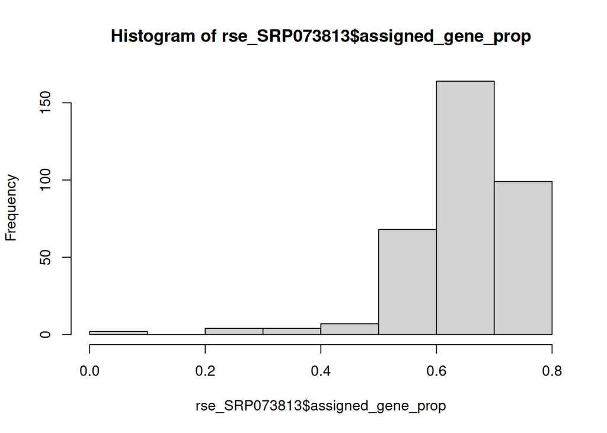

```r
hist(rse_SRP073813$assigned_gene_prop)
```

```r
table(rse_SRP073813$assigned_gene_prop < 0.2)
```

```
##
## FALSE  TRUE
##   346     2
```

```r
## There was a NA value in assigned_gene_prop
rse_SRP073813 <- rse_SRP073813[,!is.na(rse_SRP073813$assigned_gene_prop)]
rse_SRP073813 <- rse_SRP073813[,rse_SRP073813$assigned_gene_prop > 0.2]

## Search for gene means and clean them
gene_means <- rowMeans(assay(rse_SRP073813, "counts"))
summary(gene_means) ## 0.2
```

```
##      Min.   1st Qu.    Median      Mean   3rd Qu.      Max.
##       0.0       0.2       2.5     640.5     101.6 1756748.5
```

```r
rse_SRP073813 <- rse_SRP073813[gene_means > 0.2,]

## Final dimension
dim(rse_SRP073813)
```

```
## [1] 48898   346
```

```r
## Obtain final data percentage and remove rsa copy
round((nrow(rse_SRP073813)/nrow(rse_copy))*100,2)
```

```
## [1] 76.58
```

```r
remove(rse_copy)
```

# 5. Normalize data

```r
## Normalize the data using edgeR library
dge <- DGEList(
    counts = assay(rse_SRP073813, "counts"),
    genes = rowData(rse_SRP073813)
)
dge <- calcNormFactors(dge)
```

# 6. Diferential Gene Expression

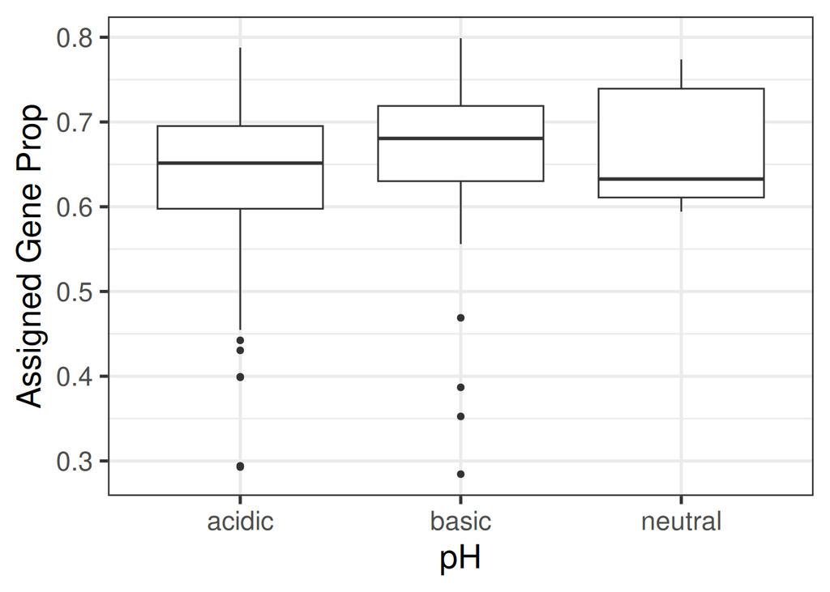

```r
## Plot the gene expression determined by the gene proportion for each pH factor
ggplot(as.data.frame(colData(rse_SRP073813)), aes(y = assigned_gene_prop, x = ph_factor)) +
    geom_boxplot() +
    theme_bw(base_size = 20) +
    ylab("Assigned Gene Prop") +
    xlab("pH")
```

```r
## Set the model.matrix object (now with the gender factor at the beginning due to the biological question adjustment)
mod <- model.matrix(~ sra_attribute.gender + ph_factor + assigned_gene_prop + sra_attribute.clinical_diagnosis,
    data = colData(rse_SRP073813)
)
colnames(mod)
```

```
## [1] "(Intercept)"
## [2] "sra_attribute.gendermale"
## [3] "ph_factorbasic"
## [4] "ph_factorneutral"
## [5] "assigned_gene_prop"
## [6] "sra_attribute.clinical_diagnosiscontrol"
## [7] "sra_attribute.clinical_diagnosismajor depression"
## [8] "sra_attribute.clinical_diagnosisschizophrenia"
```

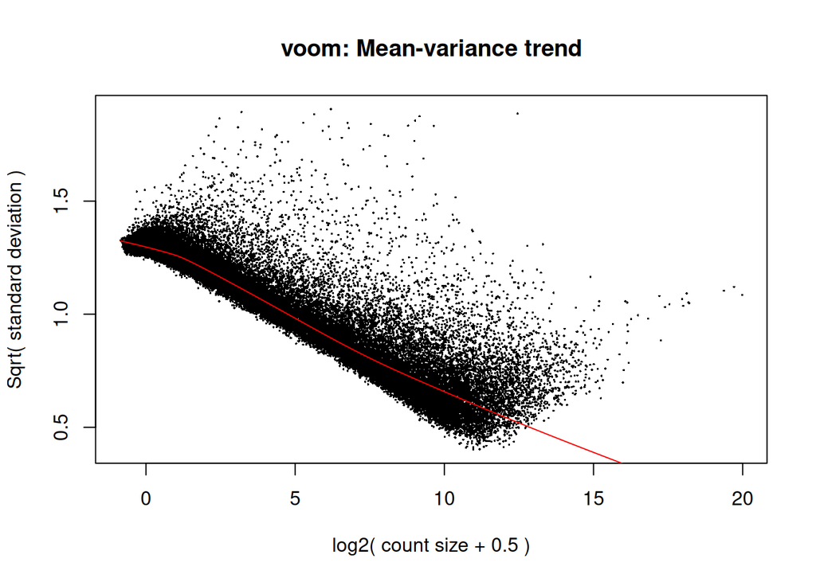

```r
## Create the mean variance trend or the differential expression analysis with Limma library
vGene <- voom(dge, mod, plot = TRUE)
```

```r
eb_results <- eBayes(lmFit(vGene))
de_results <- topTable(
    eb_results,
    coef = 2,
    number = nrow(rse_SRP073813),
    sort.by = "none"
)
dim(de_results)
```

```
## [1] 48898    16
```

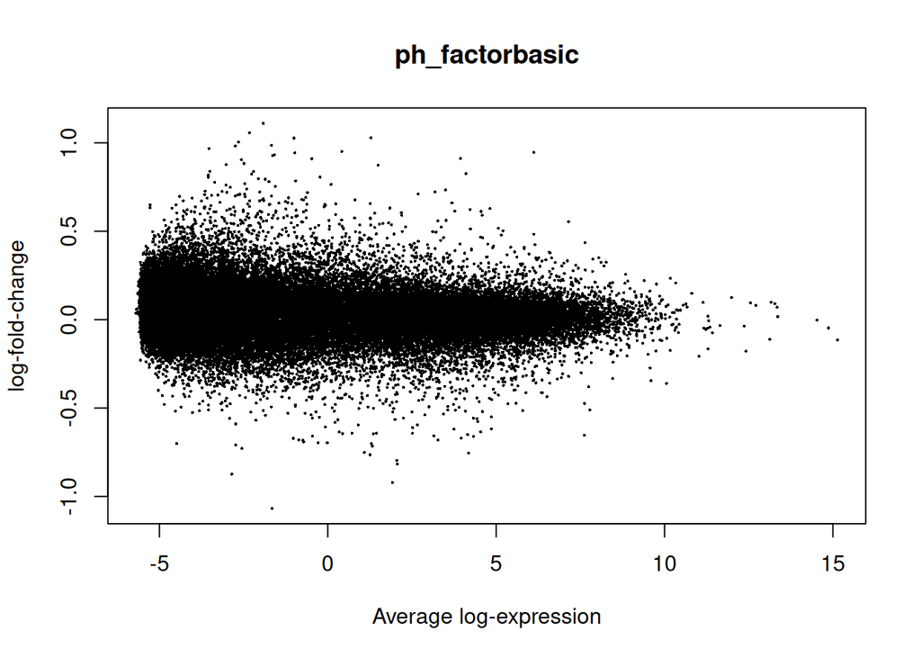

```r
## Plot the pH_factors against the acidic pH
plotMA(eb_results, coef = 3)
```

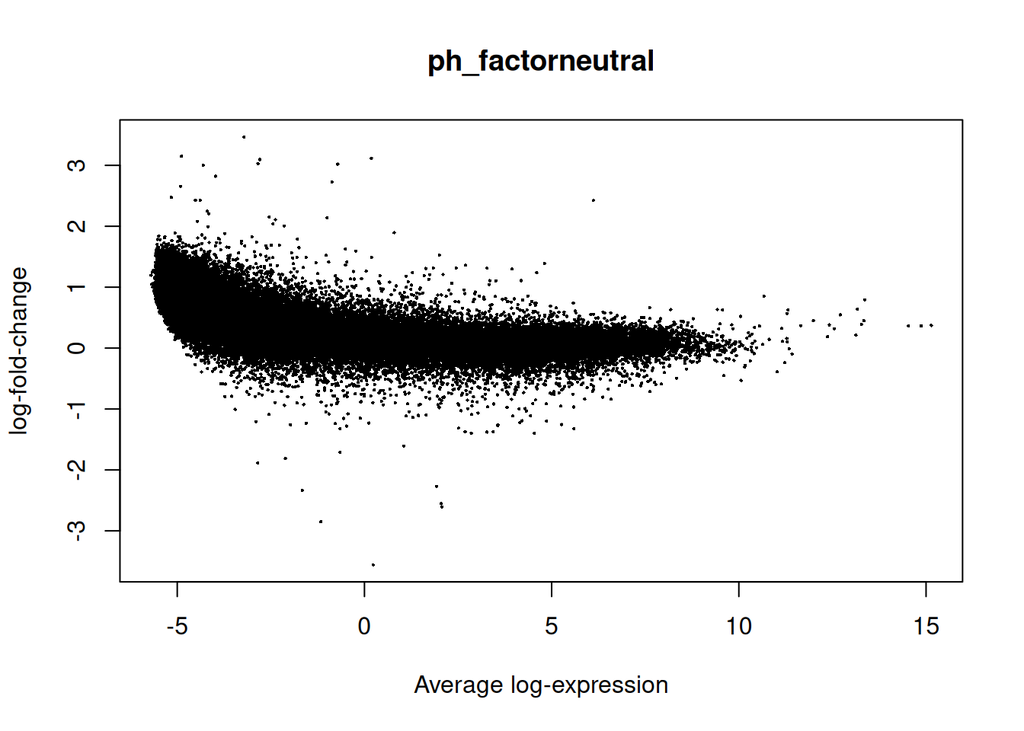

```r
plotMA(eb_results, coef = 4)
```

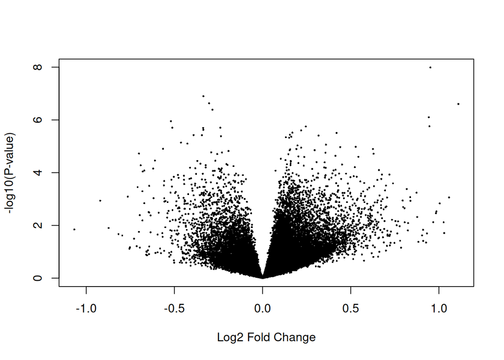

```r
volcanoplot(eb_results, coef = 3, names = de_results$gene_name)
```

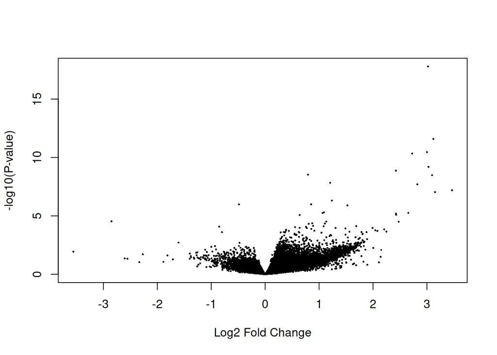

```r
volcanoplot(eb_results, coef = 4, names = de_results$gene_name)
```

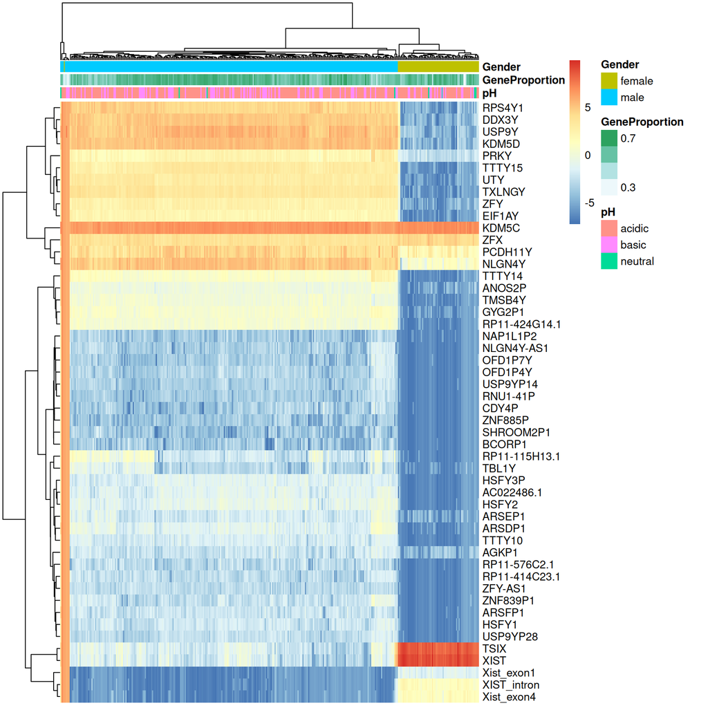

```r
## Extract the top 50 expressed genes
exprs_heatmap <- vGene$E[rank(de_results$adj.P.Val) <= 50, ]

## Create a table with the top 50 genes and set the gene name
df <- as.data.frame(colData(rse_SRP073813)[, c("ph_factor", "assigned_gene_prop", "sra_attribute.gender")])
colnames(df) <- c("pH", "GeneProportion", "Gender")
original.names <- rownames(exprs_heatmap)
rownames(exprs_heatmap) <- rowRanges(rse_SRP073813)$gene_name[
    match(rownames(exprs_heatmap), rowRanges(rse_SRP073813)$gene_id)
]

## Create the heatmap
pheatmap(
    exprs_heatmap,
    cluster_rows = TRUE,
    cluster_cols = TRUE,
    show_rownames = TRUE,
    show_colnames = FALSE,
    annotation_col = df
)
```

# 7. Conclusions

A lo largo de este proyecto se pusieron en práctica los conocimeintos obtenidos en el análisis de datos de RNAseq del proyecto: SRP073813, el cual es un dataset de 352 muestras de tejido cerebral post-mortem de humanos con condiciones clínicas. Se esperaba que hubiese algún patrón con respecto al pH reportado en los tejidos. No obstante, se encontró una expresión diferencial por el dimorfismo sexual, lo cual podría ser un objeto de estudio (como por lo general sucede en este caso particular) a futuro. El gen KDM5C, el cual codifica para una demetilasa crucial implicada en la regulación de una cascada de genes relacionados con funciones relacionadas al sistema nervioso, se encuentra con niveles de expresión similares entre los grupos. El gen ZFX que codifica para dedos de Zinc, también se encuentra con una expresión constante entre los grupos. Los genes TSIX y XIST se encuentran sobreexpresados en el grupo femenino debido al dimorfismo sexual, no obstante, esta parece ser la expresión diferencial más grande entre los grupos, por lo que su futuro estudio puede ser de importancia. Por otro lado, parece haber un patrón en la expresión diferencial por el dimorfismo sexual; el grupo de los hombres presenta niveles de expresión cercanos a 0 o sobreexpresados en la mayoría de los genes, mientras que el grupo de las mujeres presentan el patrón de expresión opuesto a lo antes descrito. Me causa curiosidad saber por qué se presentan niveles de expresión de PCDH11Y en el grupo de las mujeres cuando es un gen ligado al cromosoma Y.

Finalmente, reitero que esperaba encontrar un patrón de expresión delimitado por el pH, sin embargo, la expresión diferencial tomando en cuenta el dimorfismo sexual, fue mucho más evidente, lo que resalta la importancia de incluir a varios sexos como objeto de estudio.

Creo que el módulo me ayudó a entender de mejor manera al expresión diferencial y a saber cómo interpretarla. Espero poder tener la oportunidad de trabajar en esto más adelante.

# References

1. Wilks, C., Zheng, S.C., Chen, F.Y. et al. recount3: summaries and queries for large-scale RNA-seq expression and splicing. Genome Biol 22, 323 (2021). https://doi.org/10.1186/s13059-021-02533-6
2. Ramaker RC, Bowling KM, Lasseigne BN, Hagenauer MH, Hardigan AA, Davis NS, Gertz J, Cartagena PM, Walsh DM, Vawter MP, Jones EG, Schatzberg AF, Barchas JD, Watson SJ, Bunney BG, Akil H, Bunney WE, Li JZ, Cooper SJ, Myers RM. Post-mortem molecular profiling of three psychiatric disorders. Genome Med. 2017 Jul 28;9(1):72. doi: 10.1186/s13073-017-0458-5. PMID: 28754123; PMCID: PMC5534072.